# Hamm-institue-week3

Chris Hamm

June 17, 2016

### I am an evolutionary ecologist that works with the Lepidoptera (butterflies and moths). Evolutionary ecologist is code for “I do a lot of different things.”

Some random facts about me:

- I grew up in California
- I worked as a wildland firefighter and served in the Army
- Went to Michigan State University for grad school
- I enjoy beer and have been known to write beer inspired poetry in an attempt to win free beer (no verified video of this exists).
- I have a dog named Larry
- One goal I have for this course is to get comfortable finding geospatial data.

### Capstone Project

#### To be completely honest, I am still thinking about what I want my *Capstone* project to be because I am not entirely sure there are enough vegetation data to do what I want, but here is what I am thinking:

How are estimates of plant beta diversity (species turnover) associated between the the aerial and ground truthed data?I want to do this with a metric called Jost’ d, which is a numbers equivalent for the effective number of communities in a site. I suspect that different values of **q**, which changes the weighting given to rare species, will effect the ground truthed data more strongly than aerial data.

```r
set.seed(896234857)
# setwd("~/Desktop/Projects/NEON-2016/") # I intensely dialike that knitr and RStudio will default to the dir of the project and not listen to the setwd() command issued in the code chunk.
library("raster")
library("rgdal")
```

With our seed set and packages loaded it is time to import data. Once again I would like to state that `setwd()` should be enough for knitr to set the working directory, but nooooooo. I will figure out how to override this and post the answer.

```r
ras1 <- raster("~/Desktop/Projects/NEON-2016/NEONDI-2016/NEONdata/D17-California/TEAK/2013/lidar/TEAK_lidarDSM.tif") # import the raster image
str(ras1) # look at the structure of the data
```

```
## Formal class 'RasterLayer' [package "raster"] with 12 slots
##   ..@ file    :Formal class '.RasterFile' [package "raster"] with 13 slots
##   .. .. ..@ name        : chr "/Users/Chris/Desktop/Projects/NEON-2016/NEONDI-2016/NEONdata/D17-California/TEAK/2013/lidar/TEAK_lidarDSM.tif"
##   .. .. ..@ datanotation: chr "FLT8S"
##   .. .. ..@ byteorder   : chr "little"
##   .. .. ..@ nodatavalue : num -Inf
##   .. .. ..@ NAchanged   : logi FALSE
##   .. .. ..@ nbands      : int 1
##   .. .. ..@ bandorder   : chr "BIL"
##   .. .. ..@ offset      : int 0
##   .. .. ..@ toptobottom : logi TRUE
##   .. .. ..@ blockrows   : int 1
##   .. .. ..@ blockcols   : int 543
##   .. .. ..@ driver      : chr "gdal"
##   .. .. ..@ open        : logi FALSE
##   ..@ data    :Formal class '.SingleLayerData' [package "raster"] with 13 slots
##   .. .. ..@ values    : logi(0)
##   .. .. ..@ offset    : num 0
##   .. .. ..@ gain      : num 1
##   .. .. ..@ inmemory  : logi FALSE
##   .. .. ..@ fromdisk  : logi TRUE
##   .. .. ..@ isfactor  : logi FALSE
##   .. .. ..@ attributes: list()
##   .. .. ..@ haveminmax: logi TRUE
##   .. .. ..@ min       : num 2173
##   .. .. ..@ max       : num 2392
##   .. .. ..@ band      : int 1
##   .. .. ..@ unit      : chr ""
##   .. .. ..@ names     : chr "TEAK_lidarDSM"
##   ..@ legend  :Formal class '.RasterLegend' [package "raster"] with 5 slots
##   .. .. ..@ type      : chr(0)
##   .. .. ..@ values    : logi(0)
##   .. .. ..@ color     : logi(0)
##   .. .. ..@ names     : logi(0)
##   .. .. ..@ colortable: logi(0)
##   ..@ title   : chr(0)
##   ..@ extent  :Formal class 'Extent' [package "raster"] with 4 slots
##   .. .. ..@ xmin: num 325963
##   .. .. ..@ xmax: num 326506
##   .. .. ..@ ymin: num 4102905
##   .. .. ..@ ymax: num 4103482
##   ..@ rotated : logi FALSE
##   ..@ rotation:Formal class '.Rotation' [package "raster"] with 2 slots
##   .. .. ..@ geotrans: num(0)
##   .. .. ..@ transfun:function ()
##   ..@ ncols   : int 543
##   ..@ nrows   : int 577
##   ..@ crs     :Formal class 'CRS' [package "sp"] with 1 slot
##   .. .. ..@ projargs: chr "+proj=utm +zone=11 +datum=WGS84 +units=m +no_defs +ellps=WGS84 +towgs84=0,0,0"
##   ..@ history : list()
##   ..@ z       : list()
```

```r
ras2 <- raster("~/Desktop/Projects/NEON-2016/NEONDI-2016/NEONdata/D17-California/TEAK/2013/lidar/TEAK_lidarDTM.tif")
str(ras2)
```

```
## Formal class 'RasterLayer' [package "raster"] with 12 slots
##   ..@ file    :Formal class '.RasterFile' [package "raster"] with 13 slots
##   .. .. ..@ name        : chr "/Users/Chris/Desktop/Projects/NEON-2016/NEONDI-2016/NEONdata/D17-California/TEAK/2013/lidar/TEAK_lidarDTM.tif"
##   .. .. ..@ datanotation: chr "FLT8S"
##   .. .. ..@ byteorder   : chr "little"
##   .. .. ..@ nodatavalue : num -Inf
##   .. .. ..@ NAchanged   : logi FALSE
##   .. .. ..@ nbands      : int 1
##   .. .. ..@ bandorder   : chr "BIL"
##   .. .. ..@ offset      : int 0
##   .. .. ..@ toptobottom : logi TRUE
##   .. .. ..@ blockrows   : int 1
##   .. .. ..@ blockcols   : int 543
##   .. .. ..@ driver      : chr "gdal"
##   .. .. ..@ open        : logi FALSE
##   ..@ data    :Formal class '.SingleLayerData' [package "raster"] with 13 slots
##   .. .. ..@ values    : logi(0)
##   .. .. ..@ offset    : num 0
##   .. .. ..@ gain      : num 1
##   .. .. ..@ inmemory  : logi FALSE
##   .. .. ..@ fromdisk  : logi TRUE
##   .. .. ..@ isfactor  : logi FALSE
##   .. .. ..@ attributes: list()
##   .. .. ..@ haveminmax: logi TRUE
##   .. .. ..@ min       : num 2173
##   .. .. ..@ max       : num 2385
##   .. .. ..@ band      : int 1
##   .. .. ..@ unit      : chr ""
##   .. .. ..@ names     : chr "TEAK_lidarDTM"
##   ..@ legend  :Formal class '.RasterLegend' [package "raster"] with 5 slots
##   .. .. ..@ type      : chr(0)
##   .. .. ..@ values    : logi(0)
##   .. .. ..@ color     : logi(0)
##   .. .. ..@ names     : logi(0)
##   .. .. ..@ colortable: logi(0)
##   ..@ title   : chr(0)
##   ..@ extent  :Formal class 'Extent' [package "raster"] with 4 slots
##   .. .. ..@ xmin: num 325963
##   .. .. ..@ xmax: num 326506
##   .. .. ..@ ymin: num 4102905
##   .. .. ..@ ymax: num 4103482
##   ..@ rotated : logi FALSE
##   ..@ rotation:Formal class '.Rotation' [package "raster"] with 2 slots
##   .. .. ..@ geotrans: num(0)
##   .. .. ..@ transfun:function ()
##   ..@ ncols   : int 543
##   ..@ nrows   : int 577
##   ..@ crs     :Formal class 'CRS' [package "sp"] with 1 slot
##   .. .. ..@ projargs: chr "+proj=utm +zone=11 +datum=WGS84 +units=m +no_defs +ellps=WGS84 +towgs84=0,0,0"
##   ..@ history : list()
##   ..@ z       : list()
```

Now that the data have been imported, we can plot the two raster images and the requested histograms of the data.

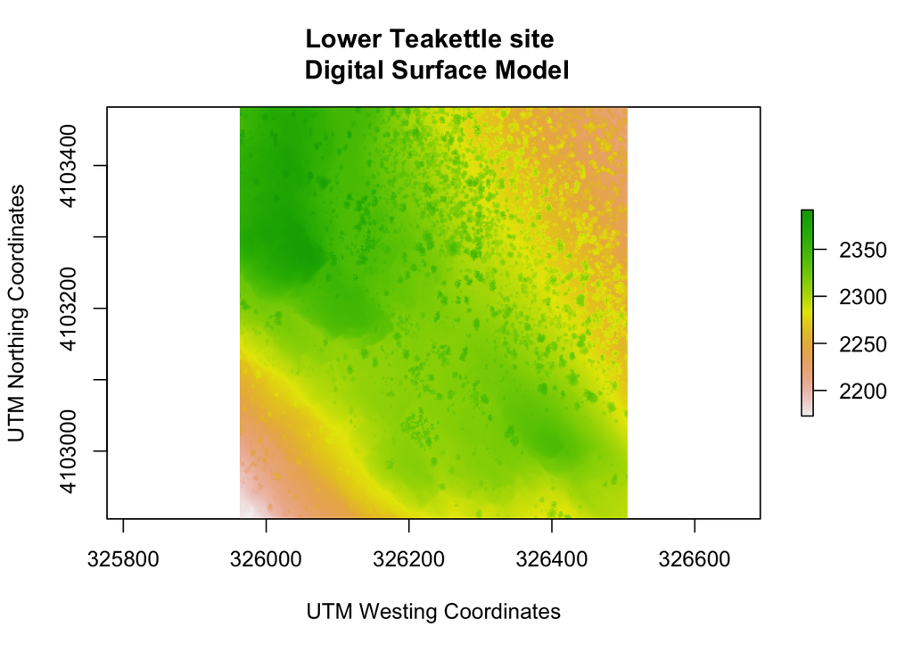

```r
# plot image 1 (DSM)
plot(ras1, main = "Lower Teakettle site \n Digital Surface Model", xlab = "UTM Westing Coordinates",
    ylab = "UTM Northing Coordinates")  # plot the image
```

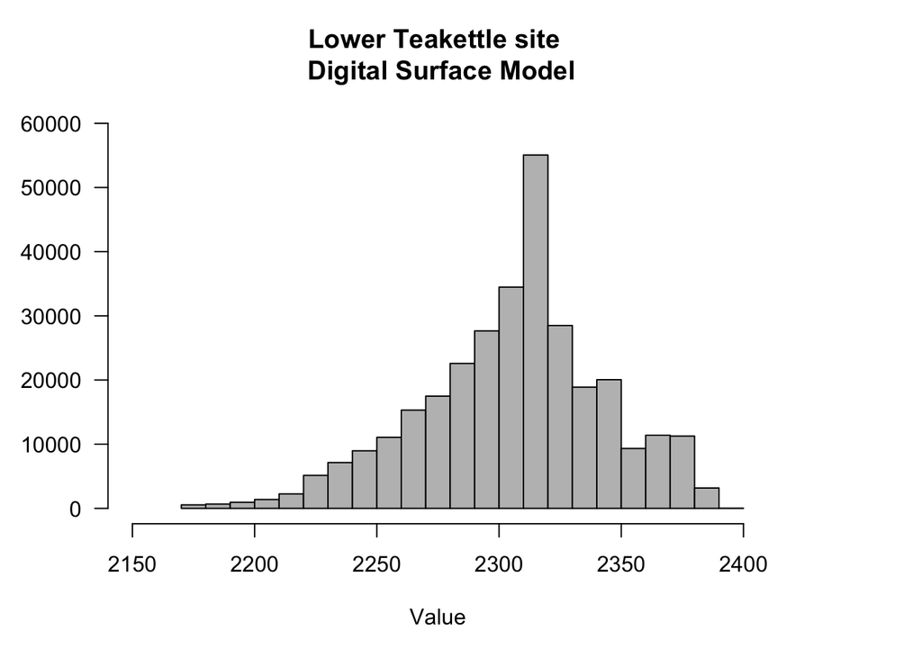

```r
hist(ras1, xlim = c(2150, 2400), ylim = c(0, 60000), las = 1, col = "grey",
    main = "Lower Teakettle site \n Digital Surface Model", xlab = "Value",
    ylab = "", maxpixels = 1e+07, breaks = "Sturges")
```

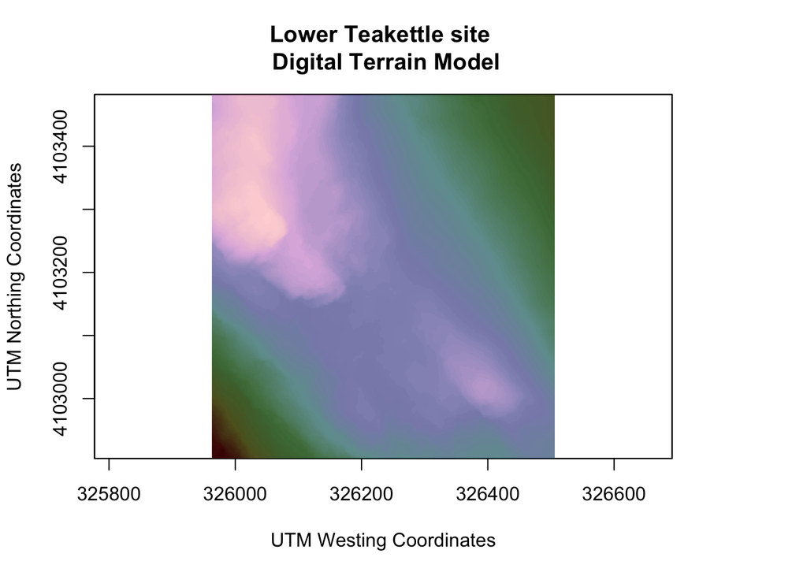

```r
# plot image 2 (DTM)
plot(ras2, main = "Lower Teakettle site \n Digital Terrain Model", xlab = "UTM Westing Coordinates",
    ylab = "UTM Northing Coordinates", col = grey(1:100/100), legend = FALSE)  # plot the image
plot(ras2, col = rainbow(100), alpha = 0.2, add = TRUE, legend = FALSE)
```

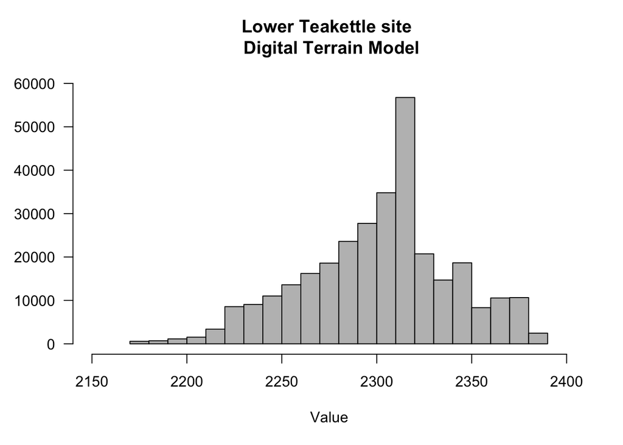

```r
hist(ras2, xlim = c(2150, 2400), ylim = c(0, 60000), las = 1, col = "grey",
    main = "Lower Teakettle site \n Digital Terrain Model", xlab = "Value",
    ylab = "", maxpixels = 1e+07, breaks = "Sturges")
```